# Predicting Google Stock Prices

## Importing Packages

```python
import numpy as np
import pandas as pd
from datetime import datetime

import matplotlib.pyplot as plt
from sklearn.linear_model import LinearRegression
from sklearn.metrics import mean_squared_error, mean_absolute_error
from itertools import combinations
```

## The Dataset

The columns of the dataset are:

- Date -- The date of the record.
- Open -- The opening price of the day (when trading starts).
- High -- The highest trade price during the day.
- Low -- The lowest trade price during the day.
- Close -- The closing price for the day (when trading is finished).
- Volume -- The number of shares traded.
- Adj Close -- The daily closing price, adjusted retroactively to include any corporate actions.

```python
#read in the dataset
stocks = pd.read_csv(r'C:\Users\njlim2\Desktop\Data Science Projects\GOOG.csv')
stocks.head(10)
```

|  | Date | Open | High | Low | Close | Adj Close | Volume |
| --- | --- | --- | --- | --- | --- | --- | --- |
| 0 | 2004-08-19 | 49.813290 | 51.835709 | 47.800831 | 49.982655 | 49.982655 | 44871361 |
| 1 | 2004-08-20 | 50.316402 | 54.336334 | 50.062355 | 53.952770 | 53.952770 | 22942874 |
| 2 | 2004-08-23 | 55.168217 | 56.528118 | 54.321388 | 54.495735 | 54.495735 | 18342897 |
| 3 | 2004-08-24 | 55.412300 | 55.591629 | 51.591621 | 52.239197 | 52.239197 | 15319808 |
| 4 | 2004-08-25 | 52.284027 | 53.798351 | 51.746044 | 52.802086 | 52.802086 | 9232276 |
| 5 | 2004-08-26 | 52.279045 | 53.773445 | 52.134586 | 53.753517 | 53.753517 | 7128620 |
| 6 | 2004-08-27 | 53.848164 | 54.107193 | 52.647663 | 52.876804 | 52.876804 | 6241307 |
| 7 | 2004-08-30 | 52.443428 | 52.548038 | 50.814533 | 50.814533 | 50.814533 | 5221498 |
| 8 | 2004-08-31 | 50.958992 | 51.661362 | 50.889256 | 50.993862 | 50.993862 | 4941252 |
| 9 | 2004-09-01 | 51.158245 | 51.292744 | 49.648903 | 49.937820 | 49.937820 | 9181687 |

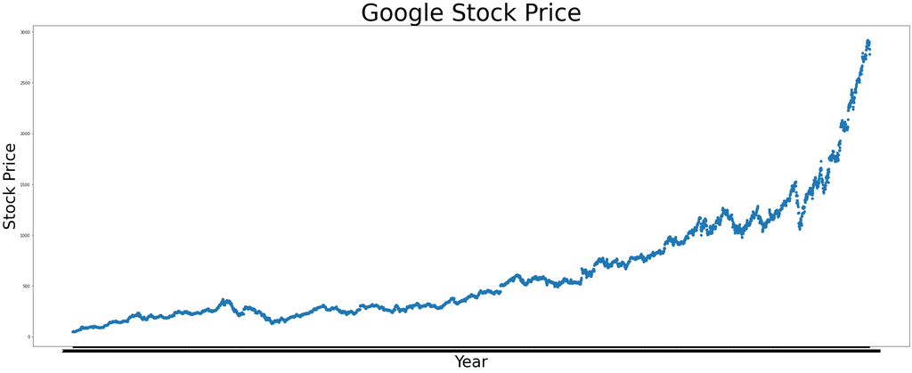

```python
#overview of the price of the stock over its lifetime
plt.figure(figsize=(40,15))
plt.scatter(x=stocks['Date'], y=stocks['Close'])
plt.title('Google Stock Price', fontsize=60)
plt.xlabel('Year', fontsize=40)
plt.ylabel('Stock Price', fontsize=40)
plt.show()
```

```python
stocks.info()
```

```
<class 'pandas.core.frame.DataFrame'>
RangeIndex: 4302 entries, 0 to 4301
Data columns (total 7 columns):
 #   Column     Non-Null Count  Dtype
---  ------     --------------  -----
 0   Date       4302 non-null   object
 1   Open       4302 non-null   float64
 2   High       4302 non-null   float64
 3   Low        4302 non-null   float64
 4   Close      4302 non-null   float64
 5   Adj Close  4302 non-null   float64
 6   Volume     4302 non-null   int64
dtypes: float64(5), int64(1), object(1)
memory usage: 235.4+ KB
```

The 'Date' column currently consists of dates that are object types. We should convert all the dates in this column to datetime objects.

```python
#convert the Date column to datetime objects
stocks['Date'] = pd.to_datetime(stocks['Date'])
print(stocks.dtypes)
```

```
Date         datetime64[ns]
Open                float64
High                float64
Low                 float64
Close               float64
Adj Close           float64
Volume                int64
dtype: object
```

One interesting thing about the dataset is how similar the 'Close' and the 'Adj Close' column values are. In the first ten rows, both of these columns contain equal values across each row. Let's check to see if this is the case across all 4302 rows. If this is the case, we can go ahead and drop one of these columns to avoid redundancy.

```python
#check to see if any rows have different prices in the 'Close' and 'Adj Close' columns
len(stocks[stocks['Close'] != stocks['Adj Close']])
```

```
0
```

```python
#drop the 'Adj Close' column
stocks = stocks.drop(labels='Adj Close', axis=1)
stocks.head(10)
```

|  | Date | Open | High | Low | Close | Volume |
| --- | --- | --- | --- | --- | --- | --- |
| 0 | 2004-08-19 | 49.813290 | 51.835709 | 47.800831 | 49.982655 | 44871361 |
| 1 | 2004-08-20 | 50.316402 | 54.336334 | 50.062355 | 53.952770 | 22942874 |
| 2 | 2004-08-23 | 55.168217 | 56.528118 | 54.321388 | 54.495735 | 18342897 |
| 3 | 2004-08-24 | 55.412300 | 55.591629 | 51.591621 | 52.239197 | 15319808 |
| 4 | 2004-08-25 | 52.284027 | 53.798351 | 51.746044 | 52.802086 | 9232276 |
| 5 | 2004-08-26 | 52.279045 | 53.773445 | 52.134586 | 53.753517 | 7128620 |
| 6 | 2004-08-27 | 53.848164 | 54.107193 | 52.647663 | 52.876804 | 6241307 |
| 7 | 2004-08-30 | 52.443428 | 52.548038 | 50.814533 | 50.814533 | 5221498 |
| 8 | 2004-08-31 | 50.958992 | 51.661362 | 50.889256 | 50.993862 | 4941252 |
| 9 | 2004-09-01 | 51.158245 | 51.292744 | 49.648903 | 49.937820 | 9181687 |

## Creating Predictor Variables

For this machine learning model, I will be using the following variables as potential predictors:

- The average price from the past 5 days.
- The average price from the past 30 days.
- The average price from the past 100 days.
- The standard deviation of the price over the past 5 days.
- The standard deviation of the price over the past 30 days.
- The standard deviation of the price over the past 100 days.

The reason for using past data for my predictors variables is because of the nature of stock market data. Stock market data is sequential, meaning that each row comes a day after the previous row. Because of this, we have to be careful not to inject any 'future' knowledge in our model. Including any current prices in our model will make our model look good, but it will make it unrealistic since we can never know the stock price upfront. As a result, we can only use prices from the past as part of our predictor variables.

```python
#add predictor variables to the dataset
def compute_avg_price_ndays(df, num_days):
    col_name = 'AVG Price ' + str(num_days) + ' days'
    for index, row in df.iterrows():
        start_index = index - num_days
        if start_index not in df.index:
            df.loc[index, col_name] = np.nan
        else:
            avg_price = df.loc[start_index:(index - 1), 'Close'].mean()
            #stock prices should only have two decimal places
            rounded_avg_price = round(avg_price, 2)
            df.loc[index, col_name] = rounded_avg_price

def compute_std_price_ndays(df, num_days):
    col_name = 'STD Price ' + str(num_days) + ' days'
    for index, row in df.iterrows():
        start_index = index - num_days
        if start_index not in df.index:
            df.loc[index, col_name] = np.nan
        else:
            std_price = df.loc[start_index:(index - 1), 'Close'].std()
            df.loc[index, col_name] = std_price
```

```python
compute_avg_price_ndays(stocks, 5)
compute_avg_price_ndays(stocks, 30)
compute_avg_price_ndays(stocks, 100)
compute_std_price_ndays(stocks, 5)
compute_std_price_ndays(stocks, 30)
compute_std_price_ndays(stocks, 100)
stocks.head(10)
```

|  | Date | Open | High | Low | Close | Volume | AVG Price 5 days | AVG Price 30 days | AVG Price 100 days | STD Price 5 days | STD Price 30 days | STD Price 100 days |
| --- | --- | --- | --- | --- | --- | --- | --- | --- | --- | --- | --- | --- |
| 0 | 2004-08-19 | 49.813290 | 51.835709 | 47.800831 | 49.982655 | 44871361 | NaN | NaN | NaN | NaN | NaN | NaN |
| 1 | 2004-08-20 | 50.316402 | 54.336334 | 50.062355 | 53.952770 | 22942874 | NaN | NaN | NaN | NaN | NaN | NaN |
| 2 | 2004-08-23 | 55.168217 | 56.528118 | 54.321388 | 54.495735 | 18342897 | NaN | NaN | NaN | NaN | NaN | NaN |
| 3 | 2004-08-24 | 55.412300 | 55.591629 | 51.591621 | 52.239197 | 15319808 | NaN | NaN | NaN | NaN | NaN | NaN |
| 4 | 2004-08-25 | 52.284027 | 53.798351 | 51.746044 | 52.802086 | 9232276 | NaN | NaN | NaN | NaN | NaN | NaN |
| 5 | 2004-08-26 | 52.279045 | 53.773445 | 52.134586 | 53.753517 | 7128620 | 52.69 | NaN | NaN | 1.760729 | NaN | NaN |
| 6 | 2004-08-27 | 53.848164 | 54.107193 | 52.647663 | 52.876804 | 6241307 | 53.45 | NaN | NaN | 0.911632 | NaN | NaN |
| 7 | 2004-08-30 | 52.443428 | 52.548038 | 50.814533 | 50.814533 | 5221498 | 53.23 | NaN | NaN | 0.889613 | NaN | NaN |
| 8 | 2004-08-31 | 50.958992 | 51.661362 | 50.889256 | 50.993862 | 4941252 | 52.50 | NaN | NaN | 1.085509 | NaN | NaN |
| 9 | 2004-09-01 | 51.158245 | 51.292744 | 49.648903 | 49.937820 | 9181687 | 52.25 | NaN | NaN | 1.284200 | NaN | NaN |

```python
#check to see if the new columns were computed correctly
print(round(stocks.iloc[0:5]['Close'].mean(), 2) == stocks.iloc[5]['AVG Price 5 days'])
print(round(stocks.iloc[0:30]['Close'].mean(), 2) == stocks.iloc[30]['AVG Price 30 days'])
print(round(stocks.iloc[0:100]['Close'].mean(), 2) == stocks.iloc[100]['AVG Price 100 days'])
```

```
True
True
True
```

## Train and Test Splits

Now it's time to split our data into a train dataset and a test dataset. But before we can do that, we should remove any rows that contain NaN values. Since we have a column that computes the average price from the past 100 days, the first 100 rows of our dataset will have NaN values in that column.

```python
#remove the rows with NaN values
stocks.dropna(inplace=True, axis=0)
stocks.isnull().sum()
```

```
Date                  0
Open                  0
High                  0
Low                   0
Close                 0
Volume                0
AVG Price 5 days      0
AVG Price 30 days     0
AVG Price 100 days    0
STD Price 5 days      0
STD Price 30 days     0
STD Price 100 days    0
dtype: int64
```

There are many different ratios we can use to split our train and test set. For this project, we will just assign 80 percent of our data to our train set and the other 20 percent to our test set. Normally we would randomize which rows go into the train set, but since our dataset has a time series nature, our train set will consist of the first 80 percent of the rows.

```python
#split dataset into a train and test set
last_train_row = int(round(len(stocks) * 0.8, 0))
train_stocks = stocks.iloc[0:last_train_row]
test_stocks = stocks.iloc[last_train_row:]
train_stocks.head(10)
```

|  | Date | Open | High | Low | Close | Volume | AVG Price 5 days | AVG Price 30 days | AVG Price 100 days | STD Price 5 days | STD Price 30 days | STD Price 100 days |
| --- | --- | --- | --- | --- | --- | --- | --- | --- | --- | --- | --- | --- |
| 100 | 2005-01-11 | 97.444756 | 98.485847 | 96.229309 | 96.408638 | 13969566 | 96.19 | 91.82 | 76.90 | 1.299797 | 4.467774 | 16.558591 |
| 101 | 2005-01-12 | 96.802162 | 97.599174 | 94.894310 | 97.325203 | 16416905 | 96.09 | 92.03 | 77.36 | 1.252097 | 4.533042 | 16.446751 |
| 102 | 2005-01-13 | 97.325203 | 98.326447 | 96.662682 | 97.300293 | 13750146 | 96.28 | 92.25 | 77.80 | 1.371988 | 4.625731 | 16.394955 |
| 103 | 2005-01-14 | 97.634041 | 99.631554 | 96.702538 | 99.611633 | 19352868 | 96.95 | 92.51 | 78.23 | 0.433825 | 4.687510 | 16.339129 |
| 104 | 2005-01-18 | 100.109764 | 102.127205 | 98.959076 | 101.569290 | 26443948 | 97.56 | 92.85 | 78.70 | 1.205485 | 4.821828 | 16.264668 |
| 105 | 2005-01-19 | 101.942894 | 102.266678 | 97.987717 | 98.281616 | 22599793 | 98.44 | 93.24 | 79.19 | 2.111473 | 5.040353 | 16.211362 |
| 106 | 2005-01-20 | 95.890579 | 97.758575 | 95.641510 | 96.597923 | 18070680 | 98.82 | 93.59 | 79.63 | 1.804095 | 5.013968 | 16.116984 |
| 107 | 2005-01-21 | 96.906769 | 97.315239 | 93.708755 | 93.788460 | 18586206 | 98.67 | 93.96 | 80.07 | 1.975663 | 4.794916 | 15.976261 |
| 108 | 2005-01-24 | 93.992691 | 94.311501 | 89.823318 | 90.022575 | 28150521 | 97.97 | 94.27 | 80.50 | 2.962888 | 4.463160 | 15.757880 |
| 109 | 2005-01-25 | 90.630295 | 90.779732 | 87.815842 | 88.229294 | 21398307 | 96.05 | 94.39 | 80.89 | 4.392815 | 4.287970 | 15.500957 |

```python
test_stocks.head(10)
```

|  | Date | Open | High | Low | Close | Volume | AVG Price 5 days | AVG Price 30 days | AVG Price 100 days | STD Price 5 days | STD Price 30 days | STD Price 100 days |
| --- | --- | --- | --- | --- | --- | --- | --- | --- | --- | --- | --- | --- |
| 3462 | 2018-05-21 | 1074.060059 | 1088.000000 | 1073.650024 | 1079.579956 | 1023200 | 1081.23 | 1053.23 | 1082.21 | 12.167969 | 27.732865 | 48.110898 |
| 3463 | 2018-05-22 | 1083.560059 | 1086.589966 | 1066.689941 | 1069.729980 | 1090000 | 1077.11 | 1055.36 | 1082.44 | 6.125027 | 27.186794 | 48.042941 |
| 3464 | 2018-05-23 | 1065.130005 | 1080.780029 | 1061.709961 | 1079.689941 | 1060700 | 1075.21 | 1056.63 | 1082.64 | 6.743661 | 26.928816 | 47.944437 |
| 3465 | 2018-05-24 | 1079.000000 | 1080.469971 | 1066.150024 | 1079.239990 | 766800 | 1074.79 | 1058.62 | 1082.95 | 6.286132 | 26.325599 | 47.818763 |
| 3466 | 2018-05-25 | 1079.020020 | 1082.560059 | 1073.775024 | 1075.660034 | 899400 | 1074.92 | 1060.18 | 1083.28 | 6.390227 | 26.108707 | 47.677741 |
| 3467 | 2018-05-29 | 1064.890015 | 1073.369995 | 1055.219971 | 1060.319946 | 1865100 | 1076.78 | 1061.73 | 1083.39 | 4.281243 | 25.583196 | 47.648357 |
| 3468 | 2018-05-30 | 1063.030029 | 1069.209961 | 1056.829956 | 1067.800049 | 1138500 | 1072.93 | 1062.47 | 1083.17 | 8.096595 | 25.190195 | 47.704130 |
| 3469 | 2018-05-31 | 1067.560059 | 1097.189941 | 1067.560059 | 1084.989990 | 3088300 | 1072.54 | 1062.26 | 1082.98 | 8.329810 | 25.115102 | 47.727657 |
| 3470 | 2018-06-01 | 1099.349976 | 1120.000000 | 1098.500000 | 1119.500000 | 2421600 | 1073.60 | 1062.69 | 1082.81 | 9.692579 | 25.398143 | 47.688550 |
| 3471 | 2018-06-04 | 1122.329956 | 1141.890015 | 1122.005005 | 1139.290039 | 1889600 | 1081.65 | 1063.75 | 1082.94 | 23.056723 | 27.085400 | 47.769216 |

## Making Predictions

Using the new predictor variables we created, let's instantiate our model and train it over the train set, and then have the computer try and predict the stock prices over the test set. For now, we will just include all six of our variables in our linear regression model.

```python
#extract the predictor columns
predictors = []
for col in stocks.columns:
    if col.startswith('AVG') or col.startswith('STD'):
        predictors.append(col)
print('predictors variables: ' + str(predictors))

#create regression model
lr = LinearRegression()
lr.fit(train_stocks[predictors], train_stocks['Close'])
predictions = lr.predict(test_stocks[predictors])
mse = mean_squared_error(test_stocks['Close'], predictions)
rmse = mse**0.5
mae = mean_absolute_error(test_stocks['Close'], predictions)
print('rmse: ' + str(rmse), '\nmae: ' + str(mae))
```

```
predictors variables: ['AVG Price 5 days', 'AVG Price 30 days', 'AVG Price 100 days', 'STD Price 5 days', 'STD Price 30 days', 'STD Price 100 days']
rmse: 36.539725584341014
mae: 26.36485733465695
```

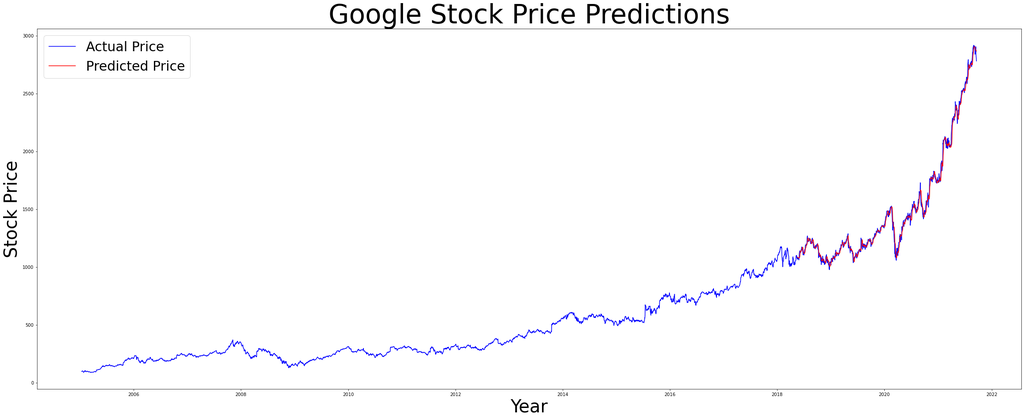

```python
#plot predicted prices vs. actual prices
plt.figure(figsize=(40,15))
plt.plot(stocks['Date'], stocks['Close'], 'b', label='Actual Price')
plt.plot(test_stocks['Date'], predictions, 'r', label='Predicted Price')
plt.title('Google Stock Price Predictions', fontsize=60)
plt.xlabel('Year', fontsize=40)
plt.ylabel('Stock Price', fontsize=40)
plt.legend(loc='upper left', fontsize=30)
plt.show()
```

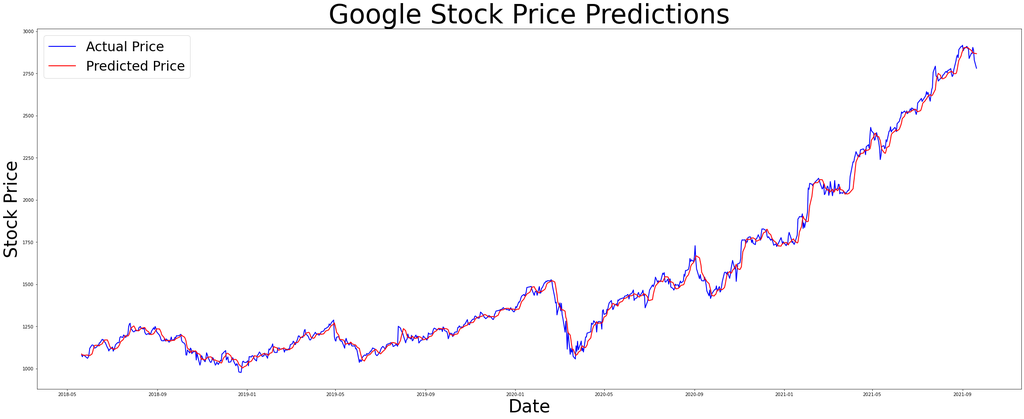

```python
#plot predicted vs. actual price only over test set
plt.figure(figsize=(40,15))
plt.plot(test_stocks['Date'], test_stocks['Close'], 'b', linewidth=2, label='Actual Price')
plt.plot(test_stocks['Date'], predictions, 'r', linewidth=2, label='Predicted Price')
plt.title('Google Stock Price Predictions', fontsize=60)
plt.xlabel('Date', fontsize=40)
plt.ylabel('Stock Price', fontsize=40)
plt.legend(loc='upper left', fontsize=30)
plt.show()
```

## Variable Selection

Although our predictions above don't look too bad, let's try to improve our model (reduce mae). There are several ways to improve a regression model, but one of the best ways is to do variable selection. In our model above we simply included all six predictors, but let's check and see if any other combinations of our predictors will result in a lower mae.

```python
#create mae calculator
def compute_mae(predictors):
    lr = LinearRegression()
    lr.fit(train_stocks[predictors], train_stocks['Close'])
    predictions = lr.predict(test_stocks[predictors])
    mae = mean_absolute_error(test_stocks['Close'], predictions)
    return mae
```

```python
mae_dict = {}
predictor_list = []
predictors = []
for col in stocks.columns:
    if col.startswith('AVG') or col.startswith('STD'):
        predictors.append(col)

#compute mae for all possible models
for i in range(1, len(predictors) + 1):
    for comb in combinations(predictors, i):
        comb_list = list(comb)
        mae = compute_mae(comb_list)
        mae_dict[tuple(comb_list)] = mae

#sort the mae_dict from lowest to highest mae
sorted_mae_dict = {k: v for k, v in sorted(mae_dict.items(), key=lambda item: item[1])}
#only print the first 10 items
{k: sorted_mae_dict[k] for k in list(sorted_mae_dict)[:10]}
```

```
{('AVG Price 5 days',
  'AVG Price 30 days',
  'AVG Price 100 days'): 25.857870930732904,
 ('AVG Price 5 days',
  'AVG Price 30 days',
  'AVG Price 100 days',
  'STD Price 30 days'): 25.860425921749012,
 ('AVG Price 5 days',
  'AVG Price 30 days',
  'AVG Price 100 days',
  'STD Price 5 days',
  'STD Price 30 days'): 25.86351468490567,
 ('AVG Price 5 days', 'AVG Price 30 days'): 25.869546137562793,
 ('AVG Price 5 days',
  'AVG Price 30 days',
  'AVG Price 100 days',
  'STD Price 5 days'): 25.871615090397185,
 ('AVG Price 5 days',
  'AVG Price 30 days',
  'STD Price 30 days'): 25.871882812776125,
 ('AVG Price 5 days',
  'AVG Price 30 days',
  'STD Price 5 days',
  'STD Price 30 days'): 25.87383372255507,
 ('AVG Price 5 days',
  'AVG Price 30 days',
  'STD Price 5 days'): 25.882519427493545,
 ('AVG Price 5 days', 'AVG Price 100 days'): 26.10464213264268,
 ('AVG Price 5 days',
  'AVG Price 100 days',
  'STD Price 30 days'): 26.10469552051069}
```

With six different predictor variables, there are a total of 63 possible models (6C1 + 6C2 + ..... + 6C6). Based on the sorted_mae_dict from above, the model that produces the lowest mae has the variables [ 'AVG Price 5 days', 'AVG Price 30 days', 'AVG Price 100 days' ]. We will use this model as our final model.

## Best Model

```python
best_predictors = ['AVG Price 5 days', 'AVG Price 30 days', 'AVG Price 100 days']

#create regression model
lr = LinearRegression()
lr.fit(train_stocks[best_predictors], train_stocks['Close'])
best_predictions = lr.predict(test_stocks[best_predictors])
mae = mean_absolute_error(test_stocks['Close'], best_predictions)
print('mae: ' + str(mae))
```

```
mae: 25.857870930732904
```

```python
lr.coef_, lr.intercept_
```

```
(array([ 1.07075323, -0.10706361,  0.03845947]), 0.1252862819479219)
```

Our linear regression model has the above coefficents and y-intercept. In other words, the predicted stock price for any given day is 1.071 *(average price over the past 5 days) - 0.107* (average price over the past 30 days) + 0.038 * (average price over the past 100 days) + 0.125.

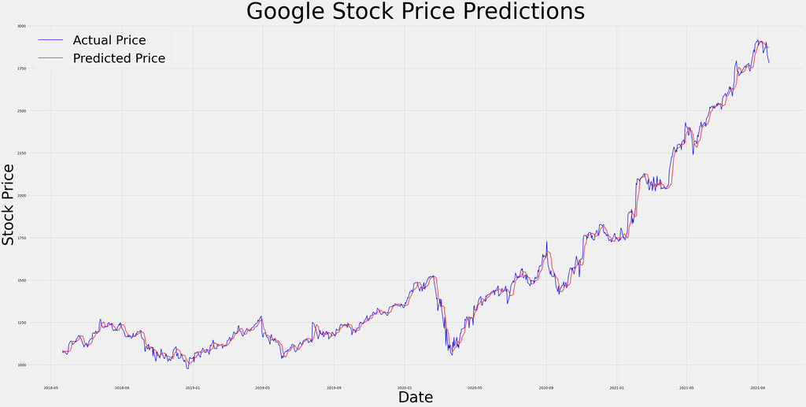

```python
#plot of our best model
plt.style.use('fivethirtyeight')
plt.figure(figsize=(50,25))
plt.plot(test_stocks['Date'], test_stocks['Close'], 'b', linewidth=2, label='Actual Price')
plt.plot(test_stocks['Date'], best_predictions, 'r', linewidth=2, label='Predicted Price')
plt.title('Google Stock Price Predictions', fontsize=90)
plt.xlabel('Date', fontsize=60)
plt.ylabel('Stock Price', fontsize=60)
plt.legend(loc='upper left', fontsize=50)
plt.show()
```

## Conclusion

The final model had a mean absolute error of 25.86. Although the error seems pretty trivial on the graph, this error is way too high for this stock price predicting model to be used in the real world. An mae of 25.86 means that your daily predictions are expected to be off by an average of 25 dollars and 86 cents, which is not ideal if you are trying to make a profit off of stocks. However, our machine learning model was still able to detect the big growths and dips in the prices, and it did a pretty good job of following the overall trend of the Google stock over its lifetime.